# Age and Performance in CS:GO

Michael Allen

4/28/2020

## Introduction

Despite the unparalleled careers of the members of the new Dignitas roster, many wrote them off as too old to compete at the highest levels of professional Counter-Strike. Only one member of the team–Håkon “hallzerk” Fjærli (19 years old)–is under 28. Of the 100 members of the current top 20 teams, only nine are 28 years or older.[^1]

[Earlier investigations](https://medium.com/@analyticalgaming/isageoverrated-fc2b58059a17) into age effects in CS:GO have examined only a single slice of time. Below I instead approach the question using individual map performance data covering 284 professional CS:GO players from 49,804 matches that occured between September 2012 and April 2020. This way we can examine the trajectory of players over time, rather than just a snapshot.

## Data

Data were collected from HLTV.org and [Liquipedia](https://liquipedia.net/counterstrike/). Following in the footsteps of the defunct Gotfrag, HLTV has become an invaluable resource for the CS:GO community. They collect and share detailed information on sometimes hundreds of matches per day. For good reason, HLTV is highly protective of this data. The data used in this analysis were collected for purley educational, non-commercial purposes. While I will share HLTV’s data, they are publically available on their website. There are numerous packages dedicated to scraping HLTV data written for a variety of languages. For those interested in how I gathered the data for this specific project, the code (written in R) is available on [GitHub](https://github.com/mmooddaa/CSGO_playerage).

### Player Sample

The players included in this analysis are limited to those who have played at least 1 map in a Major. This yields a sample of 241,872 observations (player-maps) across 284 professional CS:GO players.[^2] The sample is likely biased towards longevitiy as all of the best players to play the game have played in a Major, while many on the cusp of becoming professional. However, given the Major’s partially open qualification system, there are many players in the sample who have not achieved such an elite status. While this strategy successfuly restricts the sample to full-time, professional CS:GO players, it nevertheless leaves out a signifant chunk of the “second-tier” population of CS:GO players that play the game full time but never qualified for a Major. A future analysis may sample on participation in what HLTV codes as “Big events.” This would likely capture the second-tier as most of the players in the group will have played in a handful of such events. “LAN” and “Online” categories would likely cast too wide of a net, bringing in many amatuer players whose “career” trajectories are likely to be systematically different from that of professional players’.

*Player Age* is measured in days. Birth dates were taken from the [Liquipedia](https://liquipedia.net/counterstrike/). Eleven players are missing birth dates on Liquipedia.[^3] I estimate ages for these players by subtracting their reported age on HLTV from the date on which I checked their age (April 29, 2020). For example, I assign Otto “ottoNd” Sihvo a birth date of April 29, 1998 because HLTV reports that he is 22 years old. *Career Length* is defined as the number of days between a given map and the player’s first recored map.

### Measuring Performance

I use two measures of performance: HLTV Rating as a broad, overall measure of player performance as well as kills per round (KPR). KPR is a simple measure of a players fragging ability. This is skill is tightly connected with a player’s reaction time and cursor accuracy, both of which are expected to atrophy with age. KPR is thus an “easy” case for evaluating the effects of age on in-game performance.

Knowledge of the map and the postional tendencies of one’s opponents–these are likely to *increase* experience. So I will control for the length of career to account for the effects of experience on age. I discuss each below.

Now players develop other skills as they play the game that are likely to offset any decline in fragging ability.

#### HLTV Rating

This is due in part to its apparent simplicty. A rating of 1.00 is what an “average” player would. Anything above 1.00 is above averange and anything below is below average. Simple. But what does it mean to be “average” in this case? No one outside of HLTV knows. The biggest problem with this rating is that HLTV refuses to reveal exactly how it is calculated. No one outside of HLTV therefore has much of an idea as to what exactly this rating measures and what how the “averages” that serve as the statistics anchor are calculated.

##### What does the HLTV Rating measure?

In response to criticism that its Rating 1.0 was no more informative than simpler stats like kill-death ratio, [HLTV developed Rating 2.0](https://www.hltv.org/news/20695/introducing-rating-20). While the formula used to calculate the new Rating 2.0 is secret, an [analysis by Chris Sardegna found](https://chrissardegna.com/blog/problems-with-csgo-rating-systems/) that Rating 2.0 suffers from the same problem. While Sardegna focused on the correlation between KD ratio and HLTV Ratings 1.0 and 2.0, KPR is an even better predictor of HLTV’s Rating. Rating 2.0 and kills per round have a Pearson correlation coefficient (a simple measure of how change in one varialbe is correlated with change in another variable) of 0.92. The coefficient betwen KPR and HLTV Rating 1.0 is 0.95.

|  | KPR | KD |
| --- | --- | --- |
| HLTV Rating (pooled) | 0.92 | 0.86 |
| HLTV Rating 2.0 | 0.92 | 0.86 |
| HLTV Rating 1.0 | 0.95 | 0.87 |

The figures below illustrate what might be driving the divergence between KPR and KD using the career statistics for the long-time Swedish player, Christopher “GeT_RiGhT” Alesund.

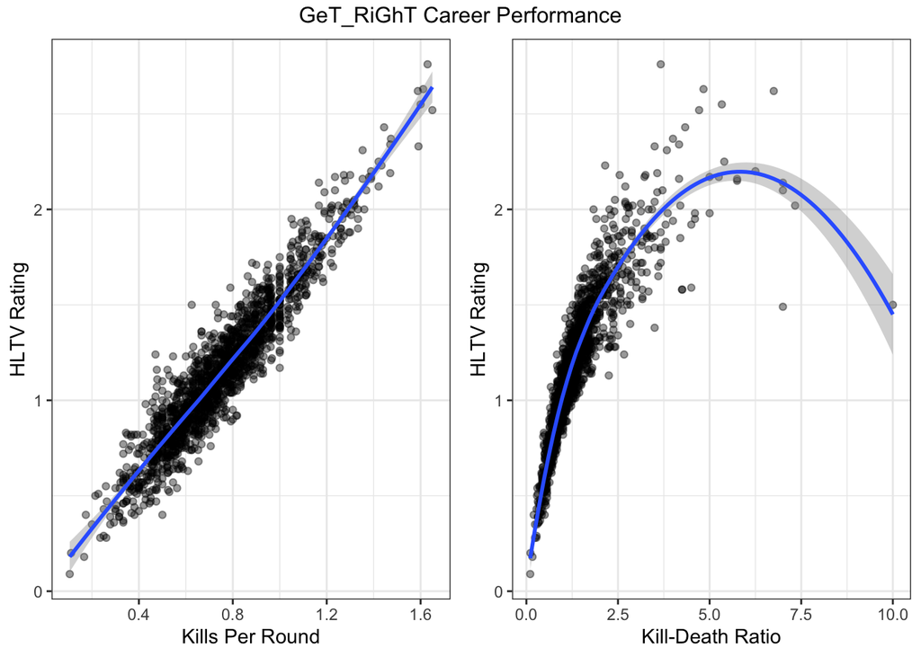

Note: Blue line plots a local polynomial regression with a bandwidth of 0.75. Shaded region is 95% confidence interval.

Likely due to the down weighting of outliers, the correlation between KD and HLTV Rating seems to breakdown for extremely high KD values.[^4] The following figure plots **actual** HLTV Ratings against an **estimate** based on a linear model regressing HLTV’s Rating on kills per round and deaths per round. The closer a given point is to the red dashed line, the more accurate the estimate is. The tight clustering around the red line means that this simple model is highly predictive of the HLTV Rating (the model has an adjusted R<sup>2</sup> of 0.93).

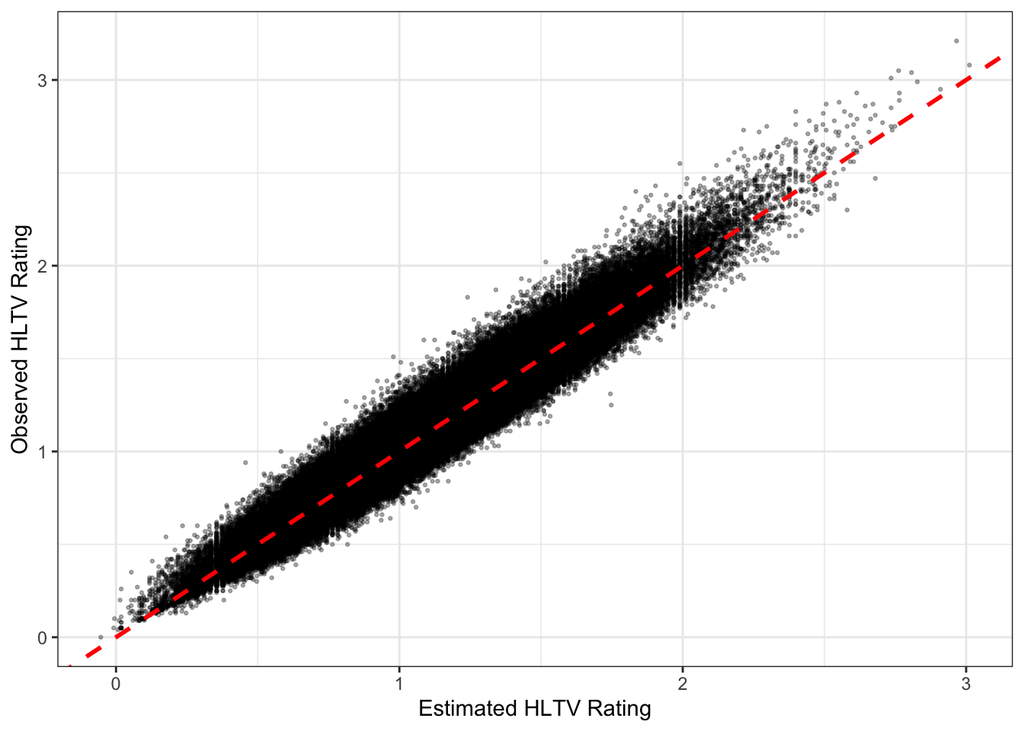

We do not know how HLTV calculates the “average” values used to anchor its Rating. Sardegna found that the averages used in Rating 1.0 were fixed at values meaningfully different from the true averages. How are different aspects of the statistic weighted? I assume that the Rating captures something outside of KPR. We should expect the Rating therefore to perhaps be more stable than KPR as a player ages given that the player may shift towards other in-game activities picked up by HLTV that go unmeasured by KPR. These include assists[^5] or what HLTV calls “impact rating,” which is a composite of events like opening kills and 1vX “wins.”[^6]

### Descriptives

Some summary statistics:

|  | N | Mean | Std. Dev. | 0% | 25% | 50% | 75% | 100% |
| --- | --- | --- | --- | --- | --- | --- | --- | --- |
| Player Age (days / 365.25) | 241872 | 23.45 | 3.18 | 13.31 | 21.12 | 23.27 | 25.66 | 33.61 |
| Career Length (days / 365.25) | 241872 | 3.29 | 1.73 | 0.00 | 1.98 | 3.12 | 4.54 | 7.62 |
| HLTV Rating (pooled) | 241872 | 1.08 | 0.35 | 0.00 | 0.85 | 1.06 | 1.29 | 3.21 |
| HLTV Rating 2.0 | 173476 | 1.10 | 0.34 | 0.05 | 0.87 | 1.08 | 1.31 | 3.21 |
| HLTV Rating 1.0 | 68396 | 1.04 | 0.36 | 0.00 | 0.80 | 1.01 | 1.26 | 2.95 |
| Kills per round | 241872 | 0.70 | 0.21 | 0.00 | 0.56 | 0.69 | 0.83 | 2.06 |

[figure not shown]

[^1]: This is based on the April 27, 2020 ranking. The players are: Finn “karrigen” Andersen (30), Chris “ChrisJ” de Jong (29), Olof “olofmeister” Kajbjer (29), Cédric “RpK” Guipouy (30), Gabriel “Fallen” Toledo (28), Fernando “fer” Alvarenga (28), Mikail “Maikelele” Bill (28), Jesse “zehN” Linjala (28), Dauren “adreN” Kystaubayev (30).
[^2]: Observations with fewer than 16 reported rounds are dropped, as are maps in which players recorded 0 deaths (this removes two maps in which jks went 17-0 and 20-0 and one map in which f0rest went 16-0).
[^3]: They are ottoNd, EXR, FeTiSh, peet, centeks, RiTz, ultra, ioRek, astaRR, RiX, and MithilF.
[^4]: This phenomenon may be why Sardegna limited his sample to only observations with a KD less than 3. Indeed, it appears that GeT_RiGhT’s HLTV Rating begins to diverge from his KD ratio around 2.5.
[^5]: When a player contributes a certain amount of damage against an opponent, but another player is credited with the kill. It is unclear if HLTV includes flash assists.
[^6]: HLTV only reports that they include “1vX wins.” Obviously, 1vX *loses* are relevant to evaluating a player’s cluch performance as well, but HLTV does not specify if loses are included in its “Impact Rating.”